# Lab 03: Data Exploration and Deterministic Functions

Analysis of Environmental Data Lab 634

Emma Zimmerman Greenlee

2021-09-22

# Lab 3 Introduction Work

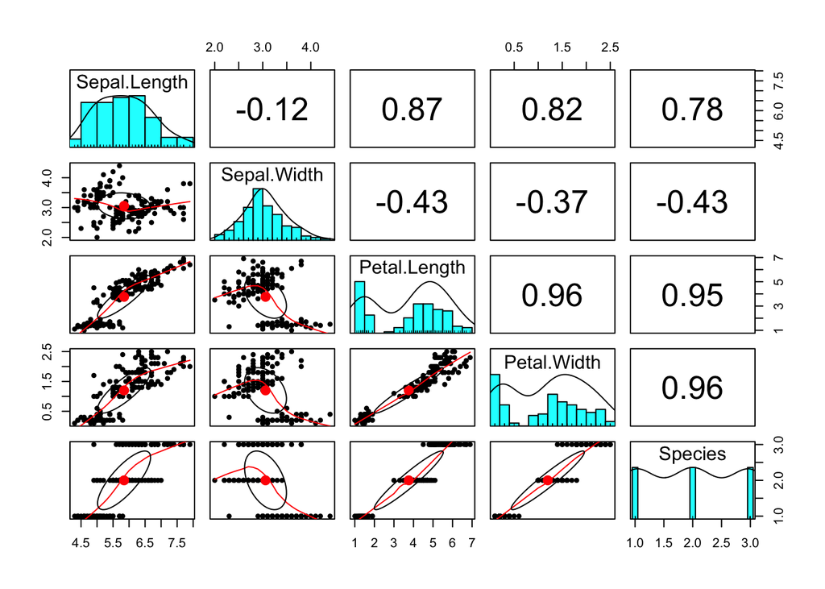

```r
# Nicer pairplots
# install.packages("psych")
require(psych)
pairs.panels(iris)
```

```r
# Data install
require(here)
dat_bird = read.csv(here("data", "bird.sta.csv"))

head(dat_bird)
```

```
##   basin sub sta AMCR AMDI AMGO AMRO BCCH BEWR BGWA BHCO BHGR BRCR BTPI BUSH
## 1     D  AL   1    0    0    0    1    0    0    0    0    2    0    0    0
## 2     D  AL   2    0    0    0    0    0    0    0    0    2    0    0    0
## 3     D  AL   3    0    0    0    0    0    1    0    0    0    0    0    0
## 4     D  AL   4    0    0    0    0    0    0    0    0    0    0    0    0
## 5     D  AL   5    0    0    0    0    0    0    0    0    0    0    0    0
## 6     D  AL   6    0    0    0    0    0    0    0    0    1    1    0    0
##   CBCH CEWA CORA COYE DEJU DOWO EUST EVGR GCKI GCSP GRJA HAFL HAWO HETH HEWA
## 1    2    0    0    0    0    0    0    0    0    0    0    0    0    0    0
## 2    2    0    0    0    0    0    0    0    0    0    0    0    2    0    0
## 3    0    0    0    0    0    0    0    0    0    0    0    0    1    0    0
## 4    1    0    0    0    0    0    0    0    0    0    0    0    0    0    0
## 5    1    0    0    0    0    0    0    0    1    0    0    0    0    0    0
## 6    0    0    0    0    0    0    0    0    0    0    0    0    0    0    0
##   HOME HOWR HUVI MALL MAMU MGWA MOQU NOFL OCWA OSFL PISI PIWO PSFL PUFI PYOW
```

[output cut: 27 more lines]

```r
dat_habitat = read.csv(here("data", "hab.sta.csv"))

head(dat_habitat)
```

```
##   basin sub sta     lat     long elev slope aspect s.id s.edge p.edge p.edge.1
## 1     D  AL   1 4924418 437009.8  542    75     15    3      E      E      131
## 2     D  AL   2 4924430 437200.6  519    80    326    2      E      E      192
## 3     D  AL   3 4924416 437430.8  584    70    230    1      I      I        0
## 4     D  AL   4 4923998 437731.0  612    60    208    3      I      E      120
## 5     D  AL   5 4923999 437544.2  580    43    235    3      I      I        0
## 6     D  AL   6 4924008 437327.2  554    65     60    3      I      E      166
##   p.cwedge ba.con ba.hard ba.snag ba.tot ba.ratio snag.sml snag.ml snag.l
## 1       79      0       5       0      5        0        7       4      0
## 2      175     18       0      18     18      100       67      46     32
## 3        0      0       0       5      0       50       14      11      4
## 4        6      9      14       0     23       40        4       4      4
## 5        0     14       0       0     14      100        0       0      0
## 6        8      9       0       5      9      100       21       7      7
##   snag.dc1 snag.dc2 snag.dc4
## 1        4        0        4
## 2       28       21       18
## 3        0        4       11
## 4        0        0        4
## 5        0        0        0
## 6        7        0       14
```

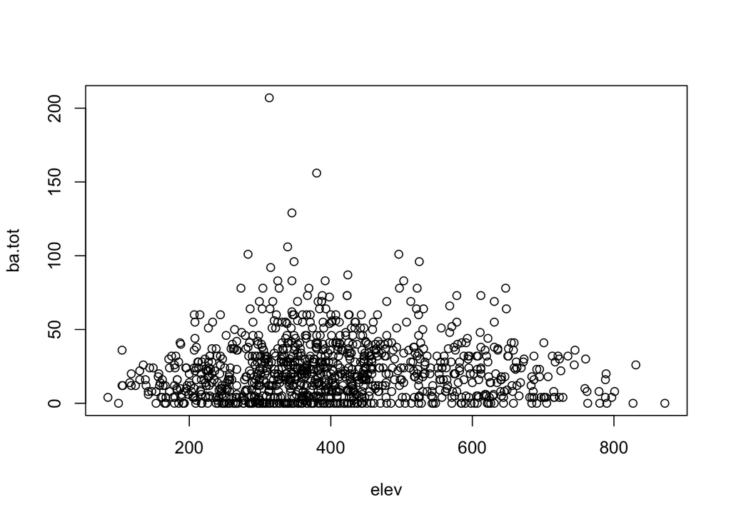

```r
# Merge the data
dat_all = merge(dat_bird, dat_habitat)

plot(ba.tot ~ elev, data = dat_all)
```

```r
# Convert bird data to presence/absence
sample(dat_all$CEWA, 100)
```

```
##   [1] 0 0 0 0 0 0 0 0 0 0 1 0 0 0 0 0 0 0 0 0 0 0 0 0 0 0 0 0 0 0 0 0 2 0 0 0 0
##  [38] 0 0 0 0 0 0 0 0 0 0 0 0 0 0 0 0 0 0 0 0 0 0 2 0 0 0 0 0 0 0 0 0 0 0 0 0 0
##  [75] 0 0 0 0 0 0 0 0 4 0 0 0 0 0 0 0 0 0 5 0 0 0 0 0 0 0
```

```r
dat_all$CEWA >= 1
```

```
##    [1] FALSE FALSE FALSE FALSE FALSE FALSE  TRUE FALSE FALSE FALSE FALSE FALSE
##   [13] FALSE  TRUE FALSE FALSE FALSE FALSE FALSE FALSE FALSE FALSE FALSE FALSE
##   [25] FALSE FALSE FALSE FALSE FALSE FALSE FALSE FALSE FALSE FALSE FALSE FALSE
##   [37] FALSE FALSE FALSE FALSE FALSE FALSE FALSE FALSE FALSE FALSE FALSE FALSE
##   [49] FALSE FALSE FALSE FALSE FALSE FALSE FALSE FALSE FALSE FALSE FALSE FALSE
##   [61] FALSE FALSE FALSE FALSE FALSE FALSE FALSE FALSE FALSE FALSE FALSE FALSE
##   [73] FALSE FALSE FALSE FALSE FALSE FALSE FALSE FALSE FALSE FALSE  TRUE  TRUE
##   [85] FALSE FALSE FALSE FALSE FALSE FALSE FALSE FALSE FALSE  TRUE FALSE FALSE
##   [97] FALSE FALSE FALSE FALSE FALSE  TRUE FALSE FALSE FALSE FALSE FALSE FALSE
##  [109] FALSE FALSE FALSE FALSE FALSE FALSE FALSE FALSE FALSE FALSE FALSE FALSE
##  [121] FALSE FALSE FALSE FALSE FALSE FALSE FALSE FALSE FALSE FALSE FALSE FALSE
##  [133] FALSE FALSE FALSE FALSE FALSE FALSE FALSE FALSE FALSE FALSE FALSE FALSE
##  [145] FALSE FALSE FALSE FALSE FALSE FALSE FALSE FALSE FALSE FALSE FALSE  TRUE
##  [157] FALSE FALSE FALSE FALSE FALSE FALSE FALSE FALSE FALSE FALSE FALSE FALSE
##  [169] FALSE FALSE FALSE FALSE FALSE FALSE FALSE FALSE FALSE FALSE FALSE FALSE
```

[output cut: 73 more lines]

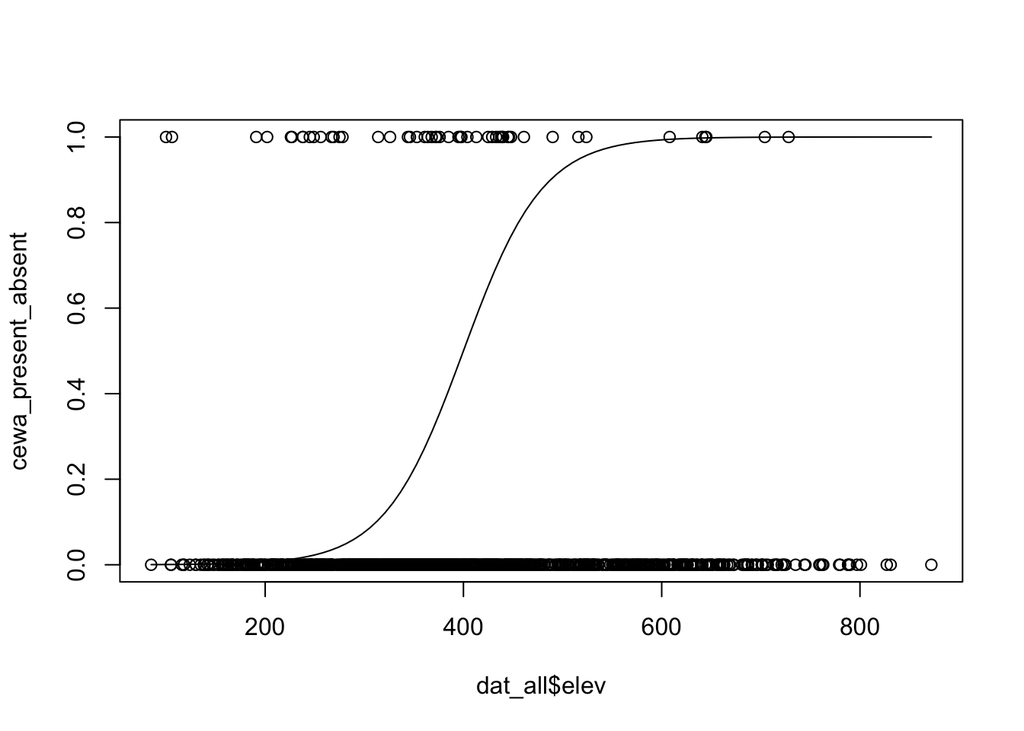

```r
# Presence/Absence
# cewa_present_absent = dat_all$CEWA >= 1

# Data type coercion
cewa_present_absent = as.numeric(dat_all$CEWA >= 1)

plot(x = dat_all$elev, y = cewa_present_absent)

# Fitting a logistic curve

# Function to calculate the logistic parameter a given the slope and midpoint
get_logistic_param_a = function(slope, midpoint)
{
  b = slope / 4
  return (-midpoint * (slope / 4))
}

# Function to calculate the logistic parameter b given the slope
get_logistic_param_b = function(slope)
{
  return (slope / 4)
}


# Calculate the value of the logistic function at x, given the parameters a and b.
logistic = function(x, a, b)
{
  val = exp(a + b * x)
  return(val / (1 + val))
}

# Calculate the value of the logistic function at x, given a slope and midpoint.
logistic_midpoint_slope = function(x, midpoint, slope)
{
  b = get_logistic_param_b(slope)
  a = get_logistic_param_a(slope, midpoint)
  return(logistic(x, a, b))
}

# Logistic Fit 1
plot(x = dat_all$elev, y = cewa_present_absent)
curve(logistic_midpoint_slope(x, midpoint = 400, slope = 0.1), add = TRUE)
```

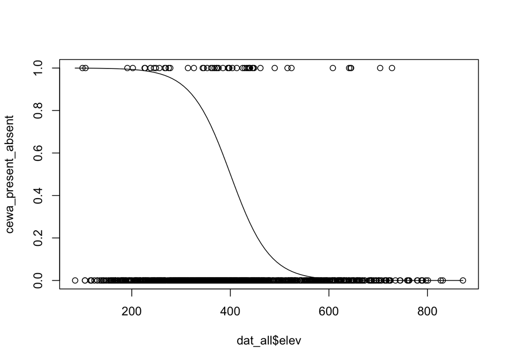

```r
# Logistic Fit 2
plot(x = dat_all$elev, y = cewa_present_absent)
curve(logistic_midpoint_slope(x, midpoint = 400, slope = -0.1), add = TRUE)
```

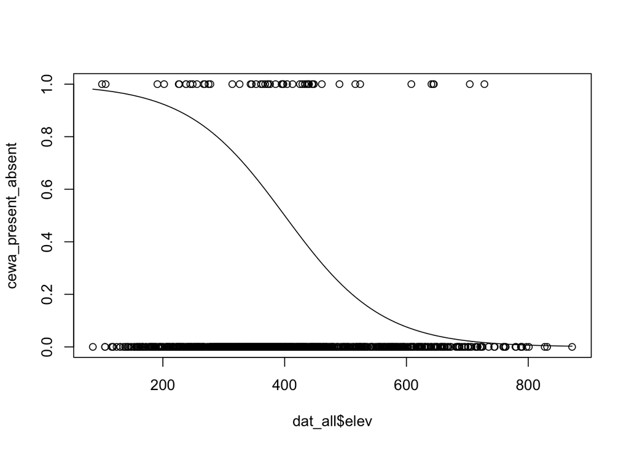

```r
# Logistic Fit 3
plot(x = dat_all$elev, y = cewa_present_absent)
curve(logistic_midpoint_slope(x, midpoint = 400, slope = -0.05), add = TRUE)
```

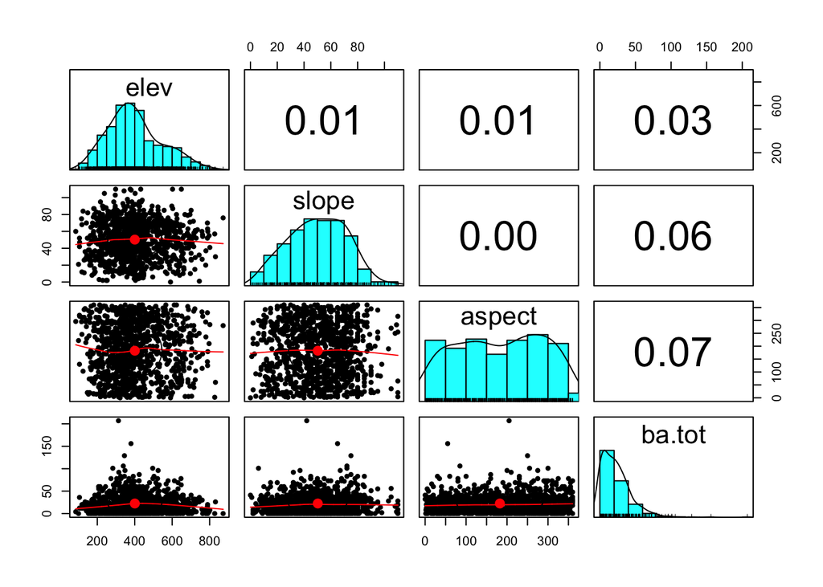

```r
# Instructions and Deliverables
# Terrain and BA plots
dat_terrain = dat_all[
  c("elev", "slope", "aspect", "ba.tot")]

pairs.panels(dat_terrain)
```

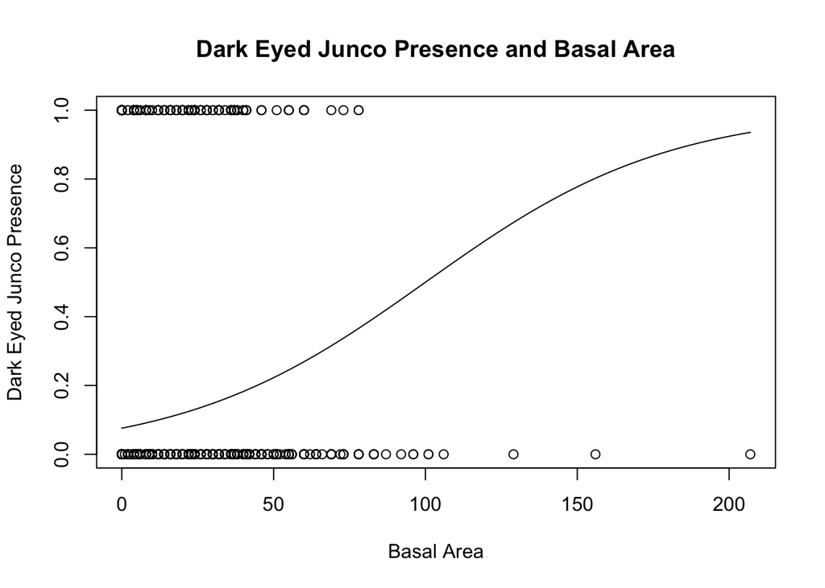

```r
#Bird Presence/Absence plots
deju_present_absent = as.numeric(dat_all$DEJU >= 1)
plot(x = dat_all$ba.tot, y = deju_present_absent, main = "Dark Eyed Junco Presence and Basal Area", xlab = "Basal Area", ylab = "Dark Eyed Junco Presence")
curve(logistic_midpoint_slope(x, midpoint = 100, slope = 0.1), add = TRUE)
```

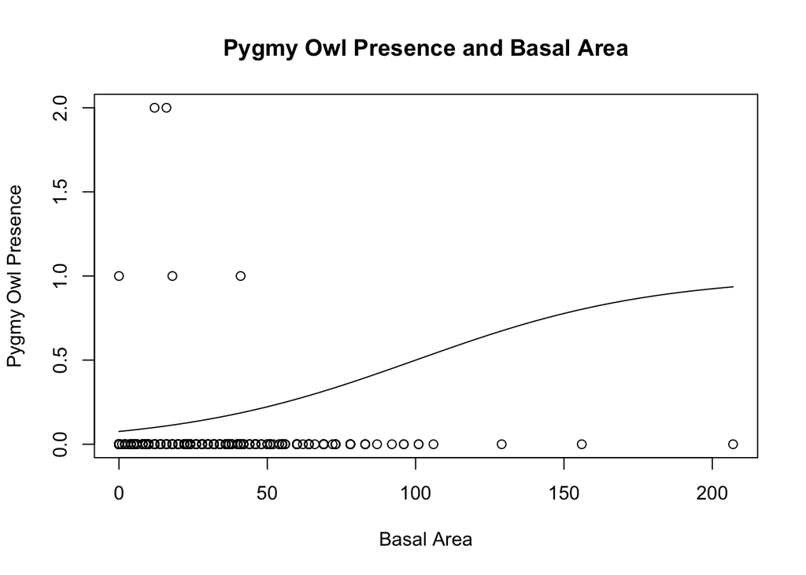

```r
pyow_present_absent = as.numeric(dat_all$PYOW >= 1)
plot(x = dat_all$ba.tot, y = dat_all$PYOW, main = "Pygmy Owl Presence and Basal Area", xlab = "Basal Area", ylab = "Pygmy Owl Presence")
curve(logistic_midpoint_slope(x, midpoint = 100, slope = 0.1), add = TRUE)
```

# Question 1

Basal area is how much space the tree takes up at its base (actually at breast height, which is 4.5 feet up the trunk). It’s measured by using the diameter of the tree to calculate its area, and is described as how much land it takes up. So, areas with high basal area have a lot of tree cover, and areas with low basal area have much less tree cover.

# Question 2

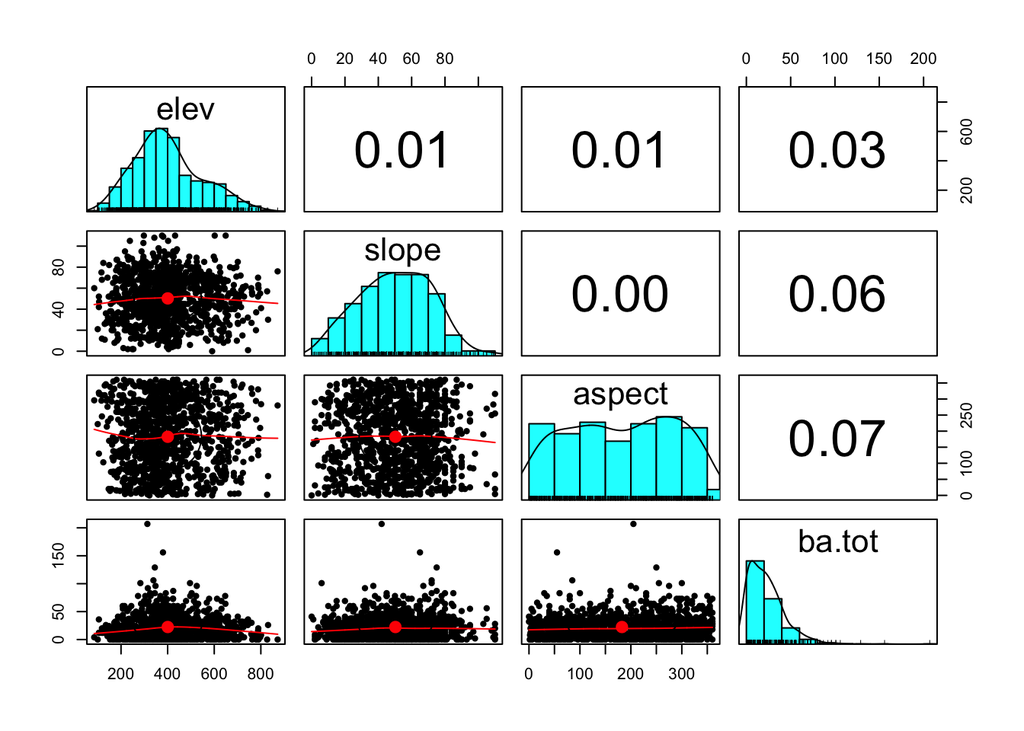

```r
dat_terrain = dat_all[
  c("elev", "slope", "aspect", "ba.tot")]

pairs.panels(dat_terrain)
```

# Question 3

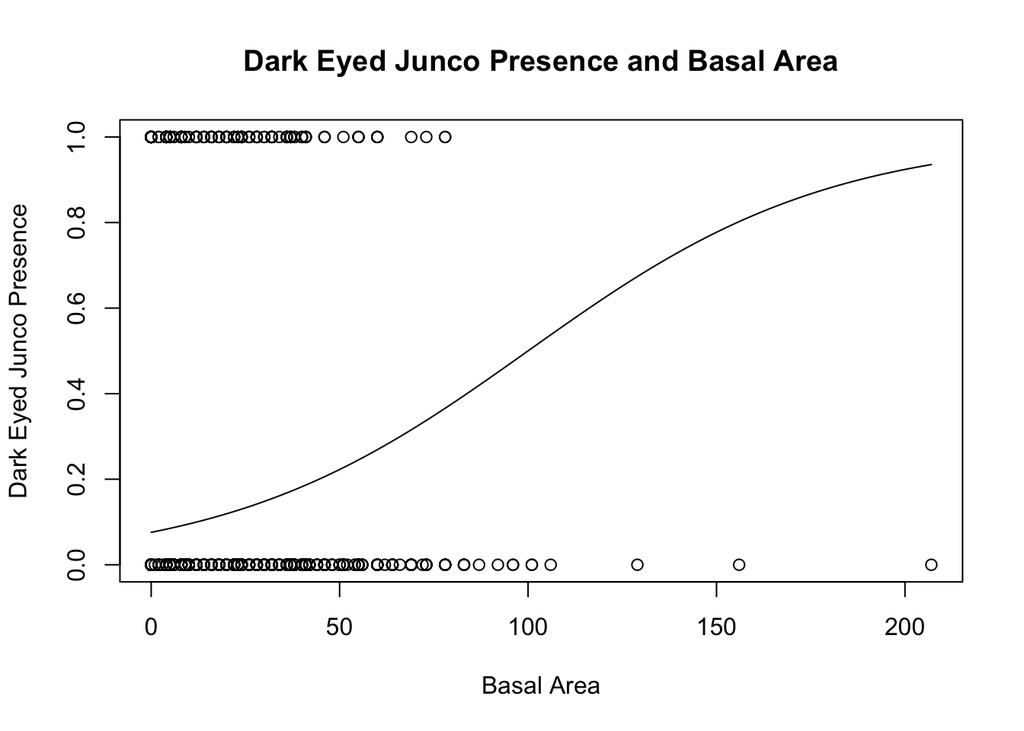

```r
deju_present_absent = as.numeric(dat_all$DEJU >= 1)
plot(x = dat_all$ba.tot, y = deju_present_absent, main = "Dark Eyed Junco Presence and Basal Area", xlab = "Basal Area", ylab = "Dark Eyed Junco Presence")
curve(logistic_midpoint_slope(x, midpoint = 100, slope = 0.1), add = TRUE)
```

# Question 4

Dark Eyed Juncos are only present at the lower basal area values, with fewer and fewer until we get to a basal area of around 80, and none after that. Most of the sites had no Dark Eyed Juncos observed, but where there were Dark Eyed Juncos, they preferred areas with low tree cover.

The fitted logistic curve looks inappropriate for the data as there are essentially only two lines of data points in this plot. Personally, I would either use a linear model to represent the data, or no model at all, as it seems very self explanatory.

# Question 5

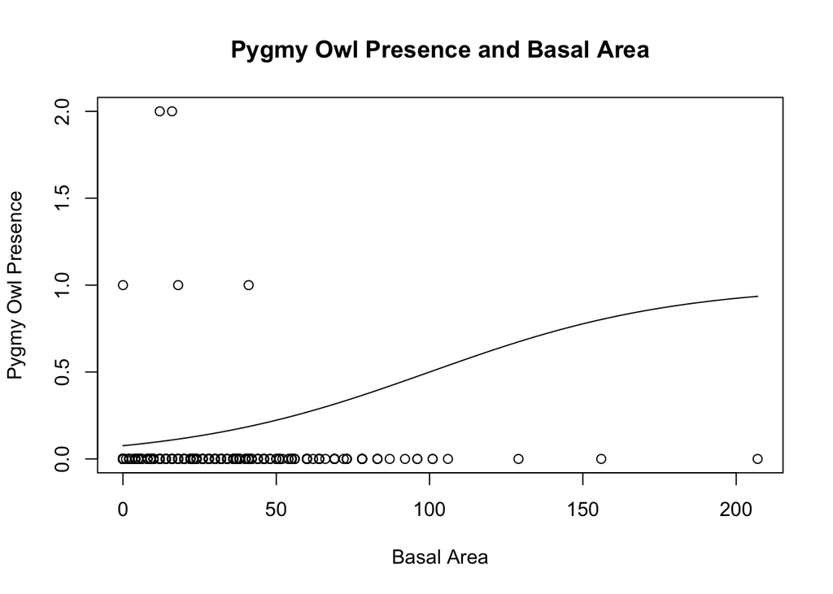

```r
pyow_present_absent = as.numeric(dat_all$PYOW >= 1)
plot(x = dat_all$ba.tot, y = dat_all$PYOW, main = "Pygmy Owl Presence and Basal Area", xlab = "Basal Area", ylab = "Pygmy Owl Presence")
curve(logistic_midpoint_slope(x, midpoint = 100, slope = 0.1), add = TRUE)
```

# Question 6

There were very few instances where there were any Pygmy Owls at all, but they were all at basal areas of less than ~60. Almost all of the sites had no observations of Pygmy Owls. From the few instances where there were Pygmy Owls observed, they seem to prefer low tree cover.

Again, the logistic model seems to be an inappropriate fit for the data. Either a linear model or none at all woul dbe better in my opinion.

# Question 7

There were a total of 181 Gray Jays that were obseved in all of the sampling sites

# Question 8

```r
sum(dat_all$GRJA)
```

```
## [1] 181
```

# Question 9

There were a total of 110 sampling sites in which Gray Jays were observed.

# Question 10

```r
sum(dat_all$GRJA >= 1)
```

```
## [1] 110
```